# SRM Ch 1

theBudgetActuary

# **What we will cover:**

#### **Chapter1: Understanding the Data** (easy)

#### Chapter2: KNN and Simple Linear Regression (medium)

#### Chapter3: Multiple Linear Regression and Variants (medium)

#### Chapter4: Time Series Data (medium)

#### Chapter5: Tree Based Algorithms (easy)

#### Chapter6: Unsupervised Models (medium-hard)

#### Chapter7: Non-Linear Models (very hard)

#### Chapter8: Miscellaneous

# **What is Statisical learning?**

##### Statistical learning is a set of tools for understanding data. The basis of this exam is to effectively analyze data and with appropriate statistical measures draw inferences and make predictions. Being able to code will not be tested on this exam.

# **Types of Variables**:

## **Quantitative:** Numerical

##### **Continuous:** A variable is said be continuous if it is numeric and can take on any real value. Ex: Amount in a bank account.

##### **Discrete:** A discrete numerical value can only take on a finite set of values. A **count** variable is discrete and can only take on positive values. Ex: Number of car accidents.

## **Qualitative:** Categorical

##### **Nominal:** Has no specific ordering such as a red paint, orange paint, or green paint.

##### **Ordinal:** Has specific ordering such as bad, medium, good.

# **2 Types of Statistical Learning Problems:**

## **1) Supervised Learning**

##### A supervised problem means we have a response variable. This means we are building a model to try to predict a certain outcome. A supervised problem can be split into two categories, regression or classification.

### **Regression:**

##### A regression problem means the response variable is quantitative. An example would be predicting a house price. Common measure of accuracy is MSE.

##### **MSE:** $\frac{1}{n}\sum_{i=1}^{n}(y_{i}-\hat{f}(x_{i}))^2$ ($James, ISLR, p.29$)

### **Classification:**

##### A classification problem means we are trying to predict a qualitative response. This variable can be binary such as a yes or no, or could be multiclass such as bad, normal, or good. Common measure of accuracy is error rate.

##### **Error rate:** $\frac{1}{n}\sum_{i=1}^{n}I(y_{i}\neq\hat{y}_{i})$ ($James, ISLR, p.37$)

##### **Bayes Classifier:** Assigns all observations to their most likely class.

##### In general, the model building process to predict the response variable, also known as the dependent variable, follows the formula:

##### **Y = f(x) + $\epsilon$** ($James, ISLR, p.16$)

- f- Systematic information that x provides about Y.
- $\epsilon$- Random component with mean 0.

##### $\epsilon$ captures all the variables that have an effect on Y that are not included in the model.

##### f is also known as the reducible error. By using different statistical learning techniques we hope to improve the accuracy of f in predicting our response. The $\epsilon$ is known as the irreducible or non-systematic error, no matter which method we choose for f(x), the variability of $\epsilon$ will not change ($James, ISLR, p.18$) .

# **Prediction Models vs Inference Models**

##### In general supervised models are built for either prediction or inference.

## **Prediction Modeling:**

##### Accuracy of the response is the most important element. How your variables interact to get this prediction is not important. An example would be finding the appropriate price to list a house.

## **Inference Modeling:**

##### How the inputs affect the response are imporant. An example would be if an extra bathroom was added to a house how much would the house value increase. In general, prediction models create more accurate responses as generally they use more complex models.

# **Parametric vs Non-Parametric Models**

##### **Parametric Models:** Have some type of functional form where we use data to estimate the parameters of that model.

##### **Non-Parametric Models:** Do not make specific assumptions about a functional form.

##### Because Non-Parametric models do not make any assumptions of the form of the model they can fit difficult problems that parametric models would not be able to. Because of this element of added **flexibility**, Non-Parametric models generally require more observations than parametric models would when making predictions. ($James, ISLR, p.23$)

## *Parametric Model Plot:*

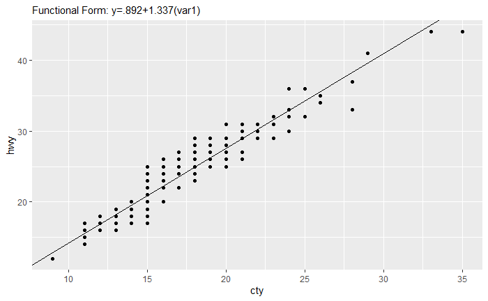

## *Non-Parametric Model Plot:*

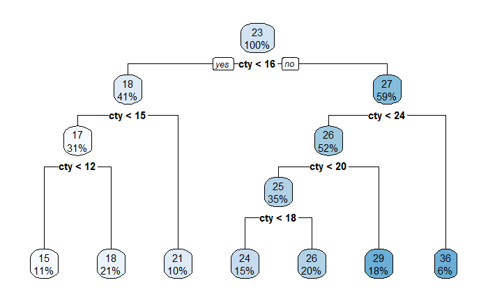

# **Flexibility vs Interpretability**

##### As a models flexibility increases, which is its ability to follow the train data, its interpretability decreases. This means as we add more and more parameters or complex functions to model data, how we get the outcome becomes harder to explain.

# **Bias-Variance Trade Off**

### **Bias:**

##### How close we can get our predictions to the actual values of the dependent variable. A positive effect of using a more flexible model is reduced bias. ($James, ISLR, p.35$).

### **Variance:**

##### The amount our model of f will change if we use a new training set. A negative effect of using a more flexible model is increased variance. ($James, ISLR, p.34$).

## **Expected Test MSE:**

##### Expected Test MSE is the average MSE we would expect if we tested our built model across a large number of training sets. It is calculated from the summation of the variance, squared bias, and error term. In order to achieve a low test MSE which is our goal, we hope to minimize both the squared bias and variance.

##### $E(y_{0}-\hat{f}(x_{0}))^{2}$ = $Var(\hat{f}(x_{0}))+[Bias(\hat{f}(x_{0}))]^{2}+Var(\epsilon)$ ($James, ISLR, p.34$)

##### Squared Bias- $[Bias(\hat{f}(x_{0}))]^{2}$

##### Variance- $Var(\hat{f}(x_{0}))$

# **2) Unsupervised Learning**

##### Unsupervised learning, unlike supervised learning, has no response variable. Instead of trying to predict a certain outcome, our focus is generally to group or find connections in our data. Since there is no response variable there is not always an easy way to measure the accuracy of our results. This can make what is defined as successful modeling somewhat arbitrary.

# **Plots**

## **Univariate Plots**

##### **Density plot-** Shows the probability density of a variable. Is a smoothed version of a histogram.

##### **Histogram-** Groups data into bins, used to show distribution of a variable.

##### **BoxPlots-** Shows the distribution of a variable with a five number summary. The left side of the rectangle represents the 25th percentile and right side of the rectangle represents the 75th percentile. The line through the rectangle represents the median. The outer lines extending from the rectangle represent the (75th percentile)+ 1.5(Interquartile Range) and (25th percentile)- 1.5(Interquartile Range). The Interquartile Range can be calculed as (75th percentile - 25th percentile). Any points beyond these lines (also known as whiskers), are considered outliers.

#### **Normally Distributed**

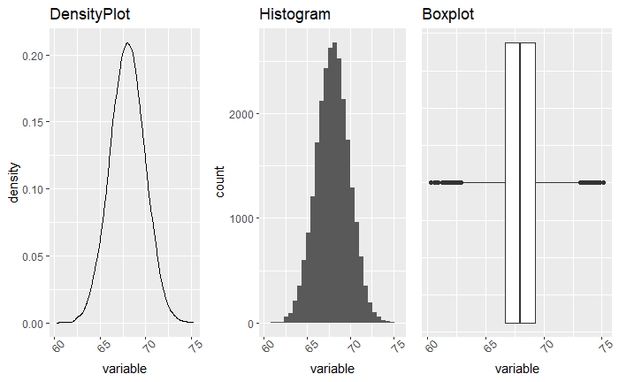

#### **Left Skewed**

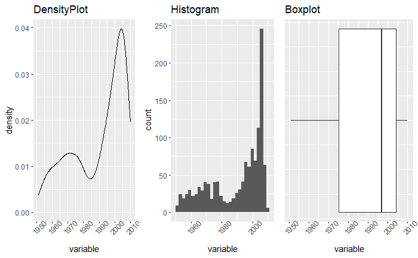

#### **Right Skewed**

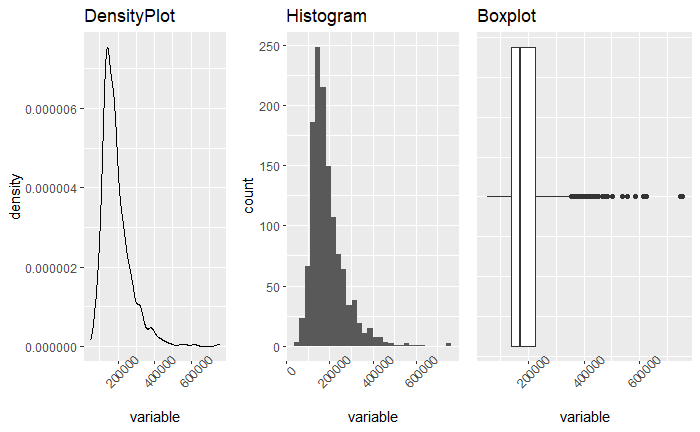

##### From the boxplot we are able to tell whether the data is skewed. If the range from median to 25th percentile is bigger than the range from the median to the 75th percentile the data left skewed. If the opposite is true the data is right skewed. (Bigger area in box to the left=left skewed, bigger area in box to the right=right skewed)

## **Q-Q Plots**

##### **Q-Q Plots-** Plots a variables distribution against a theoretical distribution. For a normal distribution the x-axis represents z scores. If the variable follows the theoretical distribution it should follow a straight line.

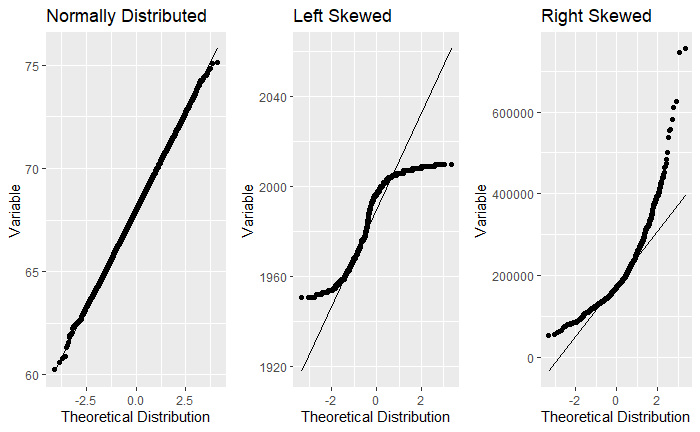

##### The graphs we have displayed thus far have all been univariate, meaning they only show one variable at a time. The following graphs will display more than one.

## **Two-Variable Plots**

### **Scatter Plots-**

##### Depicts the relationship between **two** variables.

#### **Scatter Plots**

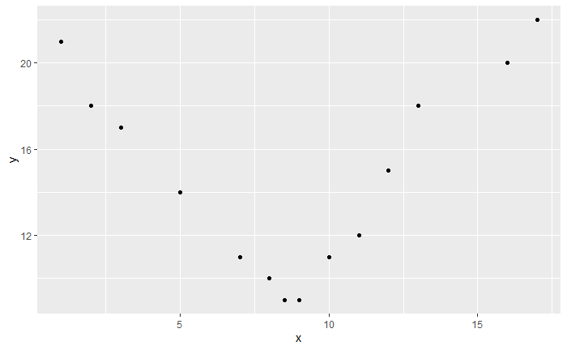

##### From a scatter plot we can see trends between variables that could give us insight in how to properly model them. For instance, we can see as x increases y decreases until x reaches about 9, in which case as x increases y increases.

# **Correlation:**

##### Measures the linear relationship between two variables. Can be positive or negative. With a scatter plot we can see the strength of correlation and spread of the variables.

##### -1 $\le$ correlation(x,y) $\le$ 1

##### **Correlation strength:**

- no correlation: |0-.3|
- weak correlation: |.3-.5|
- moderate correlation: |.5-.7|
- strong correlation: |.7-1.0|

##### If the covariance is negative the correlation is negative, if the covariance is positive the correlation is positive.

#### **Pearson’s Correlation**

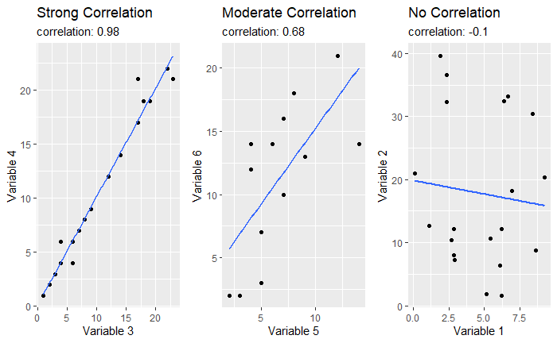

##### From the first plot we can see a strong positive linear relationship between var3 and var4. This means as var3 increases we can expect an increase in var4. Had the correlation been negative, with an increase in var3 we would expect a decrease in the value of var4. The second plot shows a positive moderate correlation between var5 and var6 while the third plot shows no correlation.

##### From the intervals of the no correlation plot we can also see that var2 has a higher variance, or spread, than var1.

##### **Correlation does not cause causation:** What is meant by this is that by lowering one variable does not mean the other will be affected.

##### Heres a famous example: On days when there are high ice cream sales there are also a large number of shark attacks. Does this mean if we stop selling ice cream the shark attack numbers go down? Probably not! Instead it is likely hot weather driving people to eat more ice cream and swim in the ocean more.

#### **Sources:**

$James, G., Witten, D., Hastie, T., &amp; Tibshirani, R. (2021). An Introduction to Statistical Leaning: With Applications in R. Springer.$